# Vaccinataion Recommendation for meningococcal disease in New South Wales

How does meningococcal disease affect a person based on age,biological sex and vaccination status

520617829

University of Sydney | DATA1001 or DATA1901 | April 2022

# 1 Client Bio & Recommendation

#### 1.0.0.1 Client Name: NSW Health

#### 1.0.0.2 Recommendation: A large number of cases from 2016-2019 consist of people who are not vaccinated against meningococcal disease and the age group at highest risk consists of zero to four year olds. It is recommended to provide vaccines for infants to contain and prevent the spread of the disease effectively.

#### 1.0.0.3 Linkedin URL: https://www.linkedin.com/company/nsw-health/?originalSubdomain=au

# 2 Evidence

```r
# Load packages
library(tidyverse)
library(readr)
library(dplyr)
library("ggplot2")
library(data.table)

# Read in the dataset (from the url or directly from the file in your folder)
disease = read.csv("http://www.maths.usyd.edu.au/u/UG/JM/DATA1001/r/current/projects/2022data/disease.csv")
```

```r
disease[ , c('Month...2', 'Serogroup' ,'IndigStatus' ,'TotalVacc' ,'MencevaxACWY','Menomune','Meningitec','Menugate','NeisVac.C','Bexsero','Menactra','Menveo','Menitorix','VaccTypeUnknown')] <- list(NULL)
```

## 2.1 Data Cleaning

### 2.1.1 All columns except six were removed and the data was grouped by New South Wales to answer the main research question.The data is succinct and readable.

## 2.2 Data Dictionary

```r
data= matrix(c('Month','Numerical','Month 1','Character', 'State','Character' , 'AgeGroup', 'Character', 'Sex', 'Character', 'VaccStatus', 'Character'), ncol=2, byrow=TRUE)

# specify the column names and row names of matrix
colnames(data) = c('column','DataType')
rownames(data) <- c('','','','','','')


# assign to table
final=as.table(data)

# display
final
```

```
##  column     DataType
##  Month      Numerical
##  Month 1    Character
##  State      Character
##  AgeGroup   Character
##  Sex        Character
##  VaccStatus Character
```

```r
df <- disease[which(disease$State == 'NSW'), ]
```

## 2.3 Focus 1:

### 2.3.1 What is the age group that is at the highest risk of contracting meningococcal disease?

#### 2.3.1.1 Knowing the age group that is at the highest risk of contracting meningococcal disease is useful to judge when it is best to provide vaccines and assess if the overall health of an individual is at risk on contracting the disease.Children from age zero to four are at the highest risk across all years, the second group is fifteen to nineteen year olds, followed by twenty to twenty four year olds.It is safe to assume that children and young adults are at the highest risk of contracting the disease.

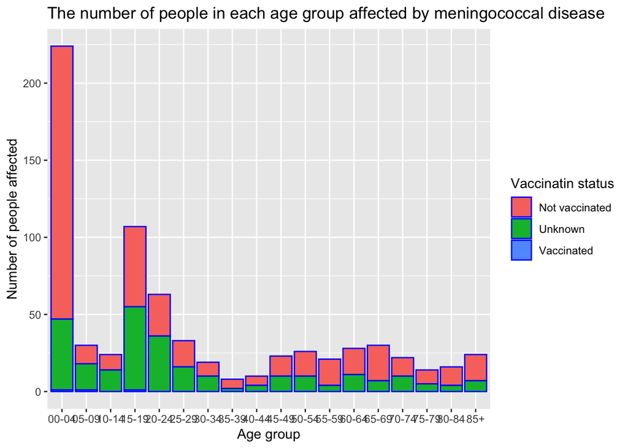

```r
ggplot(df, aes(x = AgeGroup, fill = VaccStatus ,xlab="Age groups of affected people in NSW")) +
  geom_bar(color="blue")+ggtitle("The number of people in each age group affected by meningococcal disease") +
  xlab("Age group") + ylab("Number of people affected")+labs(fill = "Vaccinatin status")
```

## 2.4 Focus 2:

### 2.4.1 Is a particular biological sex more prone to contracting meningococcal disease?

#### 2.4.1.1 Knowing if a particular biological sex is more prone to the meningococcal disease helps us to identify which groups require more resources for overall societal well being.This graph helps us to observe that while the number of people affected by the disease varies for different years being the lowest in 2013-14 and increasing upto 2017 then decreasing again, the number of males and females affected by the disease is roughly equal meaning there is no specific focus required in preventing the disease in either of the two groups.

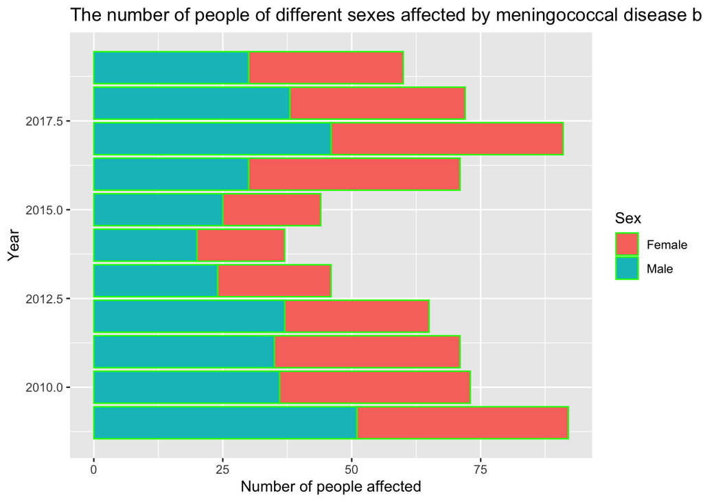

```r
ggplot(df, aes(x = Month, fill = Sex)) +
  geom_bar(color="green")+ggtitle("The number of people of different sexes affected by meningococcal disease by year") +
  xlab("Year") + ylab("Number of people affected")+coord_flip()
```

## 2.5 Focus 3:

### 2.5.1 What is the vaccination status of different people affected by meningococcal disease by year?

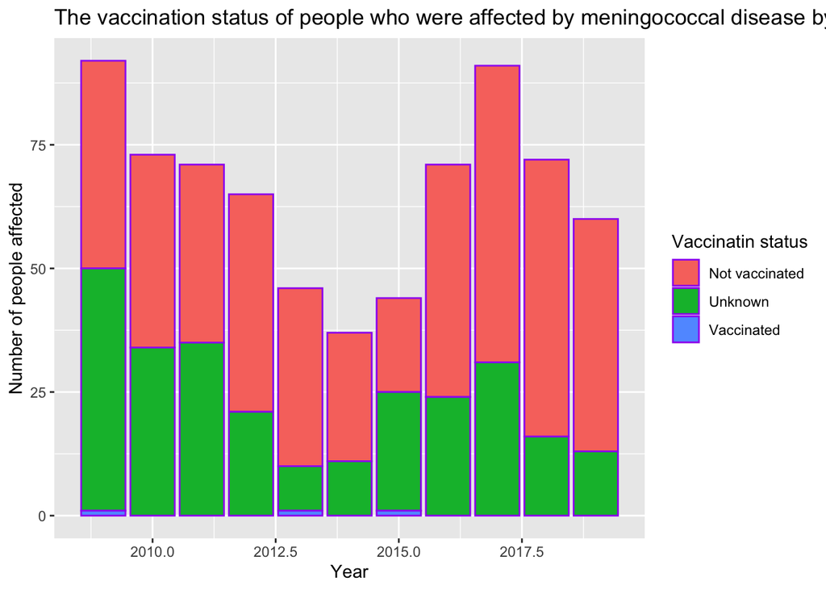

```r
ggplot(df, aes(x = Month, fill = VaccStatus)) +
  geom_bar(color="purple")+ggtitle("The vaccination status of people who were affected by meningococcal disease by year") +
  xlab("Year") + ylab("Number of people affected")+labs(fill = "Vaccinatin status")
```

# 3 Acknowledgments

####R - Bar charts - GeeksforGeeks. (2020, April 21). GeeksforGeeks. https://www.geeksforgeeks.org/r-bar-charts/